# caretPipeline

2024-08-26

#Test pipeline from caret

## Notes

- In this markdown file, we provide an example of the ‘pipeline’ capabilities in the caret package
- It allows for easy step-by-step processing of data. EG Scale the data, perform PCA, Train a classifier, Find optimal parameters via tune, present crossvalidation results.
- this is all done with minimal coding (only a few lines)

## Load Packages

```r
# Load necessary libraries
library(caret)
library(e1071)  # Required for SVM
library(pROC)   # For computing AUC
# Set a random seed for reproducibility
set.seed(123)
```

## Load Data

```r
# Load or simulate your data (here's an example with the iris dataset)
# Note: Ensure your outcome is a binary factor for AUC calculation
data(iris)
iris$Species <- ifelse(iris$Species == "setosa", "setosa", "other")
iris$Species <- as.factor(iris$Species)
```

## Set parameters for preprocessing

Common Preprocessing Options in caret: Centering and Scaling:

center: Subtracts the mean from each predictor, making the mean of the predictors zero.

scale: Divides each predictor by its standard deviation, making the predictors have a standard deviation of one.

Box-Cox Transformation:

BoxCox: Applies a Box-Cox power transformation to make the data more normally distributed.

Yeo-Johnson Transformation:

YeoJohnson: Similar to Box-Cox but can handle zero and negative values.

Imputation:

knnImpute: Imputes missing values using k-nearest neighbors. bagImpute: Imputes missing values using a bagged tree model. medianImpute: Imputes missing values by replacing them with the median.

Principal Component Analysis (PCA):

pca: Transforms the predictors into principal components. Useful for dimensionality reduction.

Independent Component Analysis (ICA):

ica: Performs Independent Component Analysis, another method for dimensionality reduction.

ZCA Whitening:

zca: Applies Zero-phase Component Analysis (ZCA) whitening, which decorrelates the data.

Spatial Sign Transformation:

spatialSign: Transforms the data to unit length while retaining the direction of the data.

Range Transformation:

range: Rescales the data to a specified range, typically [0, 1].

Correlation Filtering:

corr: Removes highly correlated features based on a specified correlation threshold.

Variance Thresholding:

nzv: Removes predictors with near-zero variance, which are not likely to be useful in modeling.

Discretization:

discretize: Converts continuous variables into categorical ones by binning.

Box-Tidwell Transformation:

BoxTidwell: Tests for and transforms nonlinear relationships between predictors and the outcome.

```r
# Define the preprocessing steps: centering, scaling, and PCA
preprocess_params <- preProcess(iris[, -5], method = c("center", "scale", "pca"))

# Apply the preprocessing steps to the data
transformed_data <- predict(preprocess_params, iris[, -5])
```

### Create Training Data

Since the caret package will perform crossvalidation for us, we create one training set and one (final) validation set.

```r
trainIndex <- createDataPartition(iris$Species, p = .8, list = FALSE, times = 1)
trainData <- transformed_data[trainIndex, ]
testData <- transformed_data[-trainIndex, ]
testSpecies <- iris[-trainIndex,]$Species

# Combine the preprocessed data with the outcome variable
training_data <- data.frame(trainData, Species = iris[trainIndex,]$Species)

# Define the control for the training process with AUC as the performance metric
train_control <- trainControl(
  method = "cv",                # Cross-validation
  number = 10,                  # 10-fold cross-validation
  summaryFunction = twoClassSummary,  # Use AUC as the performance metric
  classProbs = TRUE,            # Required for AUC
  verboseIter = TRUE            # Show training progress
)
```

## Tuning

Next we set tuning parameters to search for best parameter settings during crossvalidation. Here we use a RadialBasis SVM, so we tune parameters C (cost) and sigma (radial param). … Try different cost values and get better results :)

You can also change the performance metric, classifier, etc.

```r
# Define the grid of parameters to tune: kernel and cost
tune_grid <- expand.grid(

  # These are bad cost values ... try some closer to 1 to improve results :)
  C = 2^(-50:1:-47),#Cost parameter values

  sigma = c(0.01, 0.05, 0.1, 0.5, 1)# sigma parameter for RBF kernel
)
# Train the SVM model using the preprocessed data and tuning the parameters
svm_model <- train(
  Species ~ .,
  data = training_data,
  method = "svmRadial",           # SVM method (svmRadial is used for radial kernel)
  preProcess = NULL,              # Preprocessing already done
  tuneGrid = tune_grid,           # Parameter grid
  metric = "ROC",                 # Optimize for AUC
  trControl = train_control
)
```

## 10-fold crossvalidation AUC results for each parameter combo (via tune)

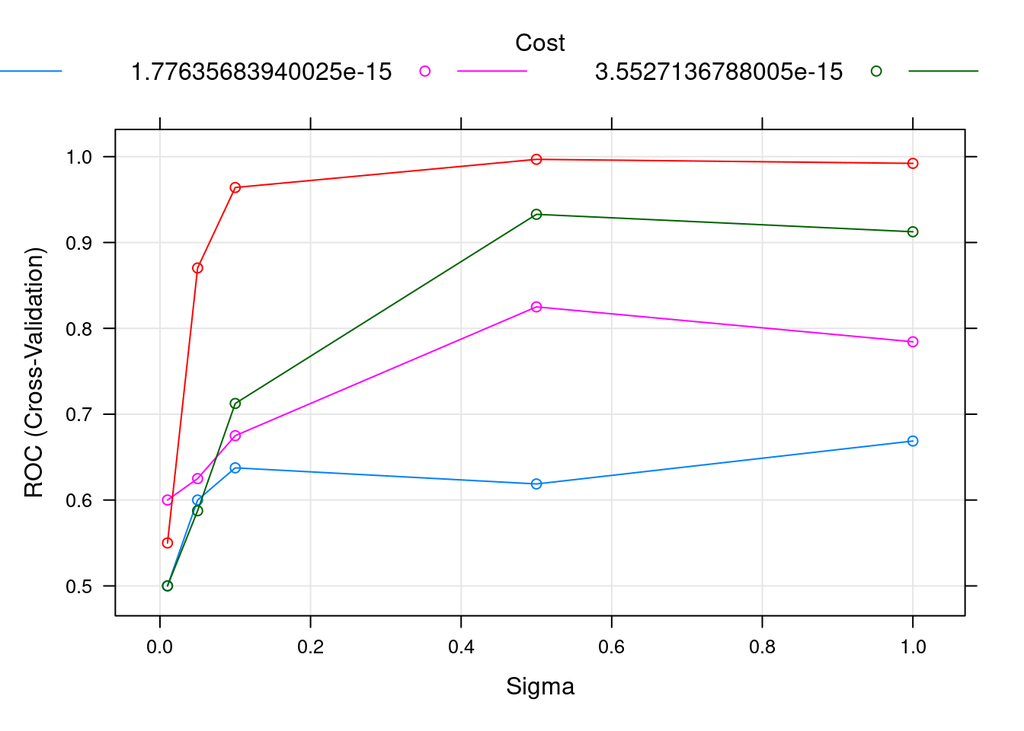

```r
# Output the best model and its parameters
#print(svm_model)

# Plot the performance of different parameter combinations
plot(svm_model)
```

```r
# Make predictions on new data (if available)
# new_data <- predict(preprocess_params, new_data_to_predict)
# predictions <- predict(svm_model, new_data)
```

## Results for a Holdout Set (Validation Set)

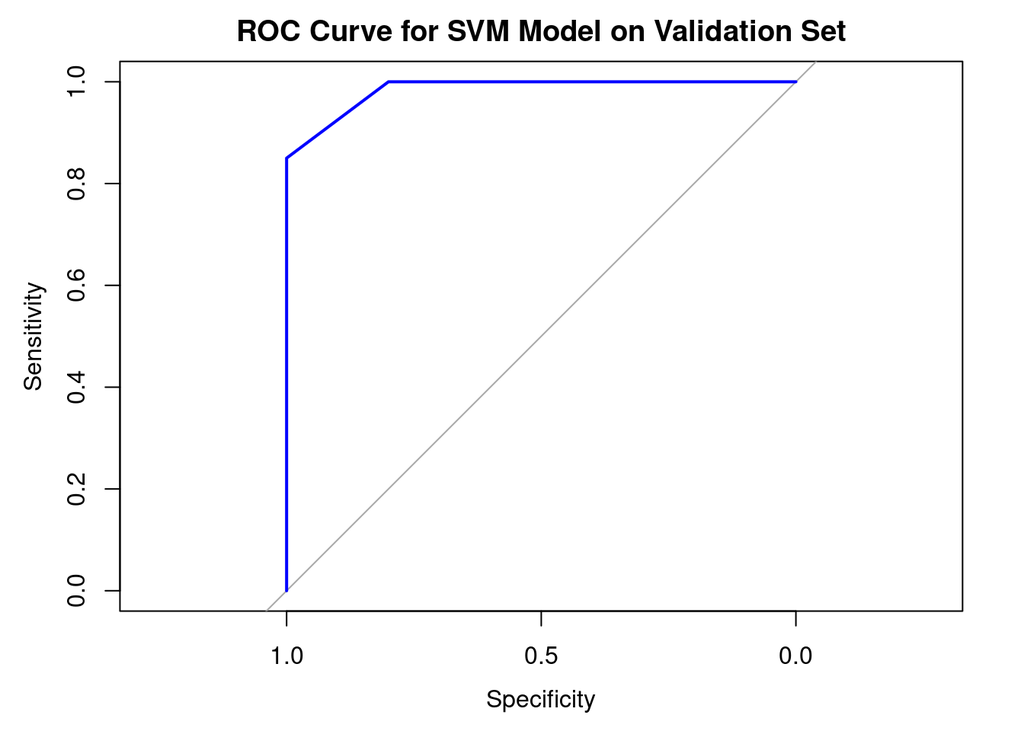

```r
predictions <- predict(svm_model, newdata = testData, type = "prob")


roc_curve <- roc(testSpecies, predictions$setosa, levels = rev(levels(testSpecies)))
# Plot the ROC curve
plot(roc_curve, col = "blue", main = "ROC Curve for SVM Model on Validation Set")
```